# Regression Workbook

Welcome to our Regression notebook. Today we will learn Basic and Regularized Regression.

## 1. Linear Regression

First let’s start with importing libraries as usual.

```python
import numpy as np
import pandas as pd

from matplotlib import pyplot as plt
%matplotlib notebook

import seaborn as sns
sns.set_style('darkgrid')
```

Let’s create a sine wave.

```python
x = np.linspace(0, 2*np.pi, 100)
```

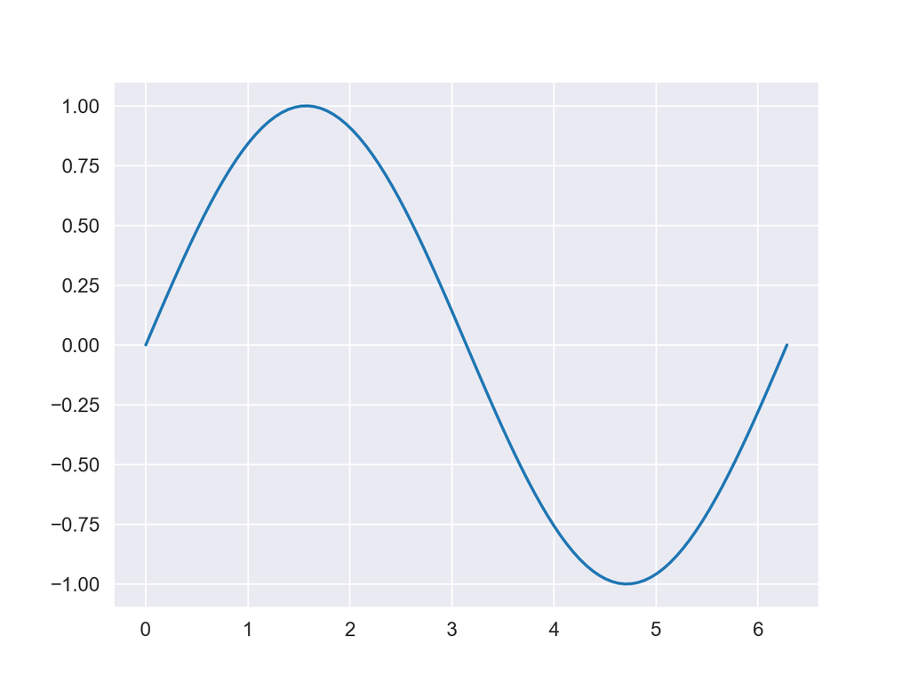

```python
plt.plot(x, np.sin(x))
```

Now let’s add some noise to the sine wave.

```python
# noise
np.random.seed(321)
noise = np.random.normal(0, .5, 100)
```

```python
# target variable
y = np.sin(x) + noise
```

Let’s save this as a new dataframe.

```python
# Create DataFrame with x and y
df = pd.DataFrame({'x' : x, 'y': y})
df.head()
```

|  | x | y |
| --- | --- | --- |
| 0 | 0.000000 | 0.086260 |
| 1 | 0.063467 | 0.881165 |
| 2 | 0.126933 | 0.145261 |
| 3 | 0.190400 | -0.252824 |
| 4 | 0.253866 | -0.320448 |

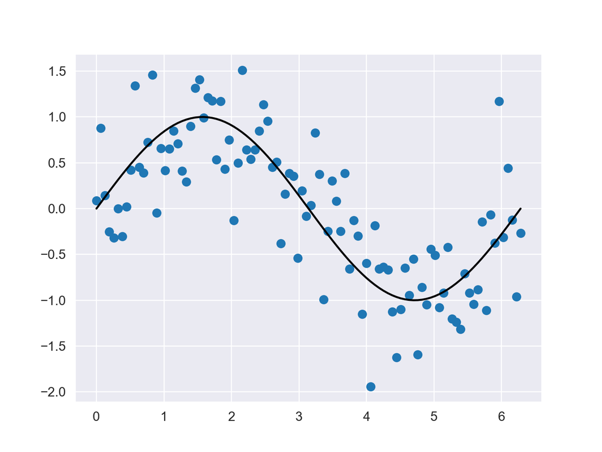

```python
# Scatterplot of x and y
plt.scatter(df.x, df.y)

# Overlay the sine wave
plt.plot(df.x, np.sin(df.x), color='k')

plt.show()
```

### 1.1 Mean model

Mean model is the most basic prediction model.

```python
# Build model
pred = np.mean(df.y)
```

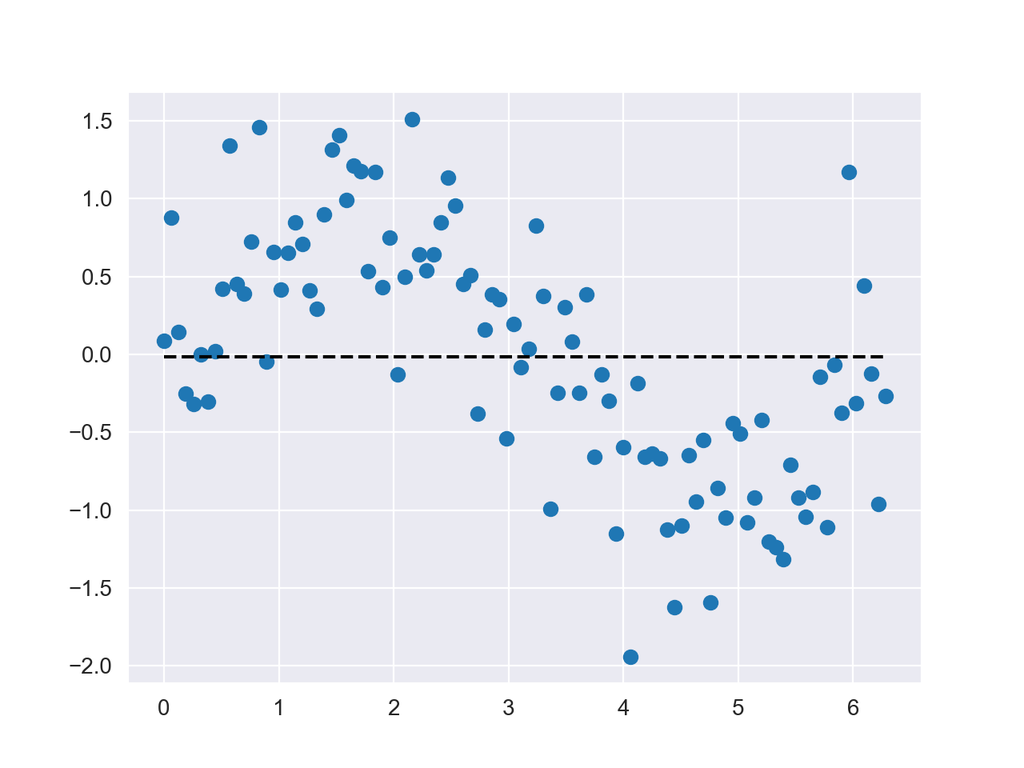

```python
# Scatterplot of x and y
plt.scatter(df.x, df.y)

# Overlay horizontal line for the prediction
plt.plot(df.x, [pred]*len(df.x), 'k--' )
plt.show()
```

What do you think about the mean model?

### 1.2 Linear Regression Model

With linear regression, we are simply trying to fit the following formula: y = w0x0 + c

```python
from sklearn.linear_model import LinearRegression
```

```python
# Initialize instance of linear regression
linear_reg_model = LinearRegression()
```

```python
# Separate our input features and target variable
features = df.drop('y', axis=1)
target = df.y
```

```python
# Fit model to the data
linear_reg_model.fit(features, target)
```

```
LinearRegression()
```

```python
print(linear_reg_model.intercept_)
print(linear_reg_model.coef_)
```

```
0.8238675120273313
[-0.26773758]
```

Let’s see what these values are on the plot!

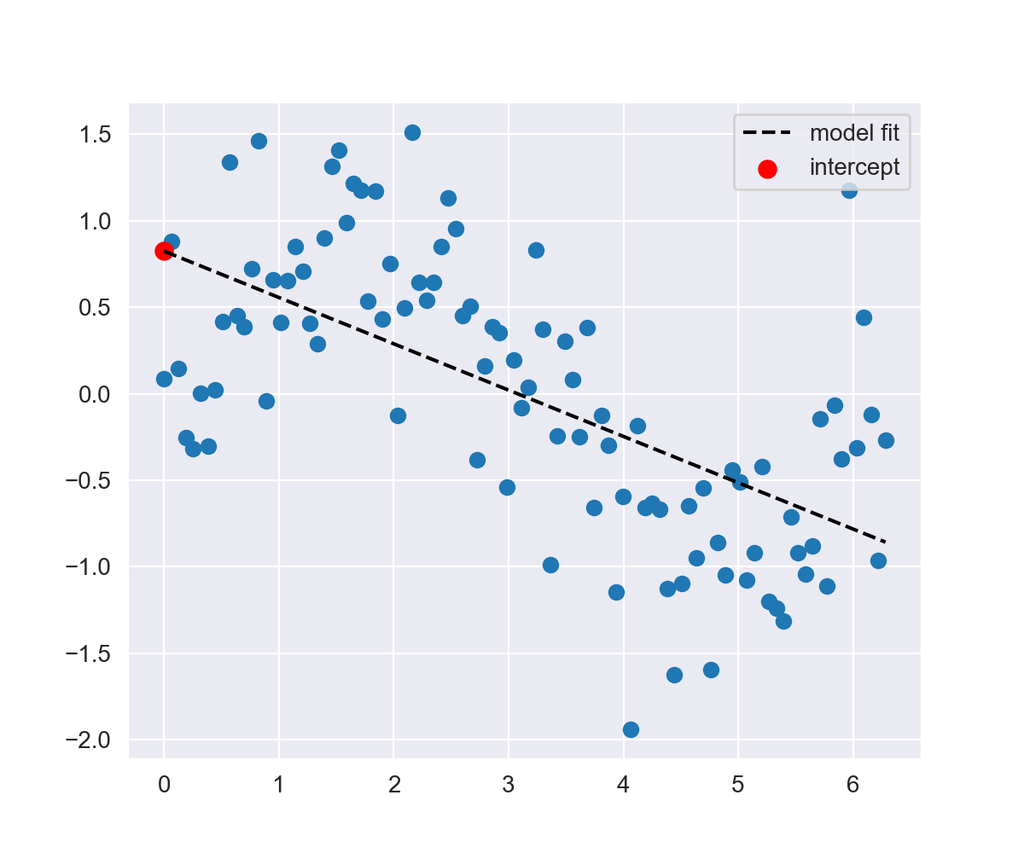

```python
fig = plt.figure(figsize=[6,5])

ax = plt.subplot(111)
# Plot original points
ax.scatter(df.x, df.y)
# Plot predicted values of y
ax.plot(df.x, linear_reg_model.predict(features), 'k--', label='model fit')
ax.scatter(0,linear_reg_model.intercept_, s=50, c='r', label='intercept')

ax.legend(loc=1)
plt.show()
```

```python
print(linear_reg_model.intercept_ + 5*linear_reg_model.coef_)
```

```
[-0.51482041]
```

```python
print(linear_reg_model.predict(np.zeros([1,1])+5))
```

```
[-0.51482041]
```

## 2. Polynomial Regression

With polynomial regression, we are simply trying to fit the following formula: y = wx + wx^2 + c

```python
# Make a copy of df
df_poly = df.copy()
```

```python
# Create the x^2 input feature
df_poly['x2'] = np.power(df_poly.x, 2)
```

```python
df_poly.head()
```

|  | x | y | x2 |
| --- | --- | --- | --- |
| 0 | 0.000000 | 0.086260 | 0.000000 |
| 1 | 0.063467 | 0.881165 | 0.004028 |
| 2 | 0.126933 | 0.145261 | 0.016112 |
| 3 | 0.190400 | -0.252824 | 0.036252 |
| 4 | 0.253866 | -0.320448 | 0.064448 |

```python
linear_model = LinearRegression()

features = df_poly.drop('y', axis=1)
target = df_poly.y

linear_model.fit(features, target)
```

```
LinearRegression()
```

```python
fig = plt.figure(figsize=[6,5])

ax = plt.subplot(111)
# Plot original points
ax.scatter(df_poly.x, df_poly.y)
# Plot predicted values of y
ax.plot(df_poly.x, linear_model.predict(features), 'k--', label='model fit')
ax.scatter(0,linear_model.intercept_, s=50, c='r', label='intercept')

ax.legend(loc=1)
plt.show()
```

[output not shown]

### Higher order polynomials

Well that was a bit disappointing. Let’s see how we can predict these curves in the data.

```python
third_order_df = df.copy()
```

```python
third_order_df['x2'] = np.power(third_order_df.x, 2)
```

```python
third_order_df['x3'] = np.power(third_order_df.x, 3)
```

```python
features = third_order_df.drop('y', axis=1)
target = third_order_df.y
```

```python
third_order_model = LinearRegression()
```

```python
third_order_model.fit(features, target)
```

```
LinearRegression()
```

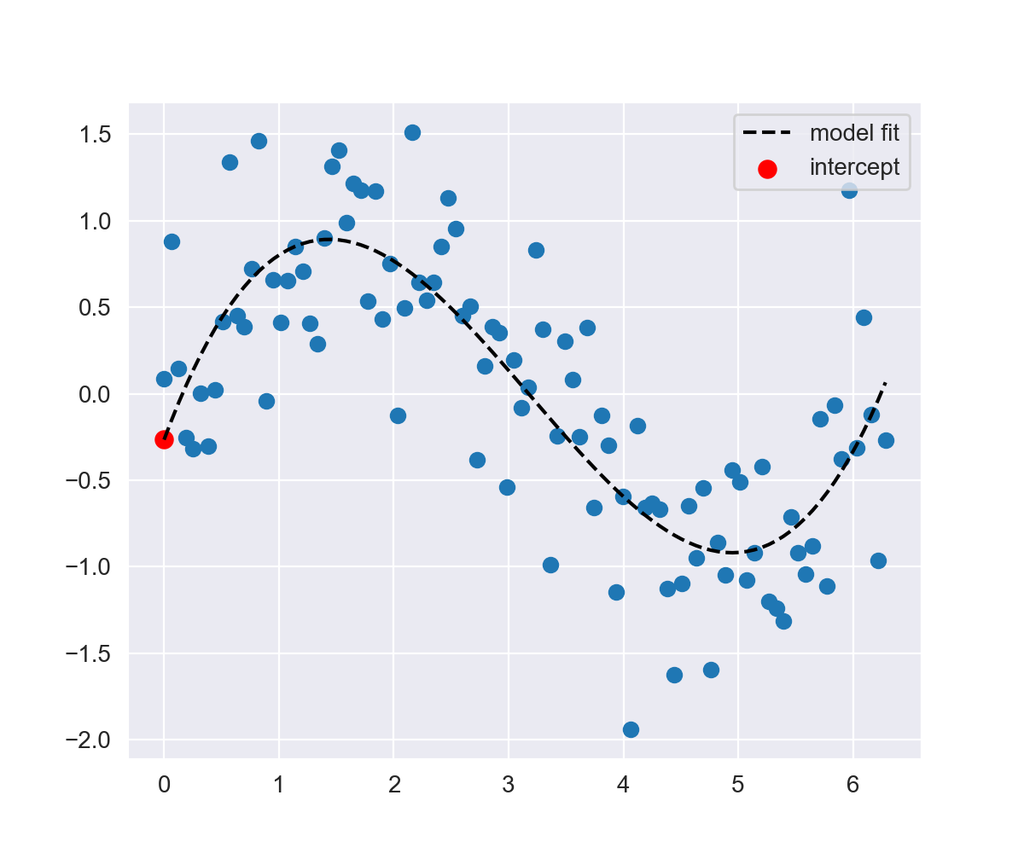

```python
fig = plt.figure(figsize=[6,5])

ax = plt.subplot(111)
# Plot original points
ax.scatter(df_poly.x, df_poly.y)
# Plot predicted values of y
ax.plot(third_order_df.x, third_order_model.predict(features), 'k--', label='model fit')
ax.scatter(0,third_order_model.intercept_, s=50, c='r', label='intercept')

ax.legend(loc=1)
plt.show()
```

How do we make it so that we don’t have to increase the lines of code we write exponentially as we increase the order?

## 3. Logistic Regression

```python
from sklearn.linear_model import LogisticRegression
```

```python
# Logistic regression
model = LogisticRegression()
```

```python
model.fit(features, target)
```

```
ValueError: Unknown label type: 'continuous'
```

What does this error mean?

```python
print(target)
```

```
0     0.086260
1     0.881165
2     0.145261
3    -0.252824
4    -0.320448
        ...
95   -0.312249
96    0.443255
97   -0.122903
98   -0.961879
99   -0.268629
Name: y, Length: 100, dtype: float64
```

```python
target_categorical = np.zeros(len(target))
```

```python
for i in range(len(target)):
    if (target[i] <=0.):
        target_categorical[i] = 0
    else:
        target_categorical[i] = 1
```

```python
print(target_categorical, target_categorical.dtype)
```

```
[1. 1. 1. 0. 0. 1. 0. 1. 1. 1. 1. 1. 1. 1. 0. 1. 1. 1. 1. 1. 1. 1. 1. 1.
 1. 1. 1. 1. 1. 1. 1. 1. 0. 1. 1. 1. 1. 1. 1. 1. 1. 1. 1. 0. 1. 1. 1. 0.
 1. 0. 1. 1. 1. 0. 0. 1. 1. 0. 1. 0. 0. 0. 0. 0. 0. 0. 0. 0. 0. 0. 0. 0.
 0. 0. 0. 0. 0. 0. 0. 0. 0. 0. 0. 0. 0. 0. 0. 0. 0. 0. 0. 0. 0. 0. 1. 0.
 1. 0. 0. 0.] float64
```

```python
target_categorical = target_categorical.astype(int)
```

```python
print(target_categorical, target_categorical.dtype)
```

```
[1 1 1 0 0 1 0 1 1 1 1 1 1 1 0 1 1 1 1 1 1 1 1 1 1 1 1 1 1 1 1 1 0 1 1 1 1
 1 1 1 1 1 1 0 1 1 1 0 1 0 1 1 1 0 0 1 1 0 1 0 0 0 0 0 0 0 0 0 0 0 0 0 0 0
 0 0 0 0 0 0 0 0 0 0 0 0 0 0 0 0 0 0 0 0 1 0 1 0 0 0] int64
```

```python
model.fit(features, target_categorical)
```

```
LogisticRegression()
```

```python
# predict()
model.predict(features)
```

```
array([1, 1, 1, 1, 1, 1, 1, 1, 1, 1, 1, 1, 1, 1, 1, 1, 1, 1, 1, 1, 1, 1,
       1, 1, 1, 1, 1, 1, 1, 1, 1, 1, 1, 1, 1, 1, 1, 1, 1, 1, 1, 1, 1, 1,
       1, 1, 1, 1, 1, 1, 1, 0, 0, 0, 0, 0, 0, 0, 0, 0, 0, 0, 0, 0, 0, 0,
       0, 0, 0, 0, 0, 0, 0, 0, 0, 0, 0, 0, 0, 0, 0, 0, 0, 0, 0, 0, 0, 0,
       0, 0, 0, 0, 0, 0, 0, 0, 0, 0, 0, 0])
```

```python
# # predict_proba()
model.predict_proba(features[:10])
```

```
array([[0.15195352, 0.84804648],
       [0.14040579, 0.85959421],
       [0.13045881, 0.86954119],
       [0.12191011, 0.87808989],
       [0.11458442, 0.88541558],
       [0.10833136, 0.89166864],
       [0.10302282, 0.89697718],
       [0.09855037, 0.90144963],
       [0.09482285, 0.90517715],
       [0.09176414, 0.90823586]])
```

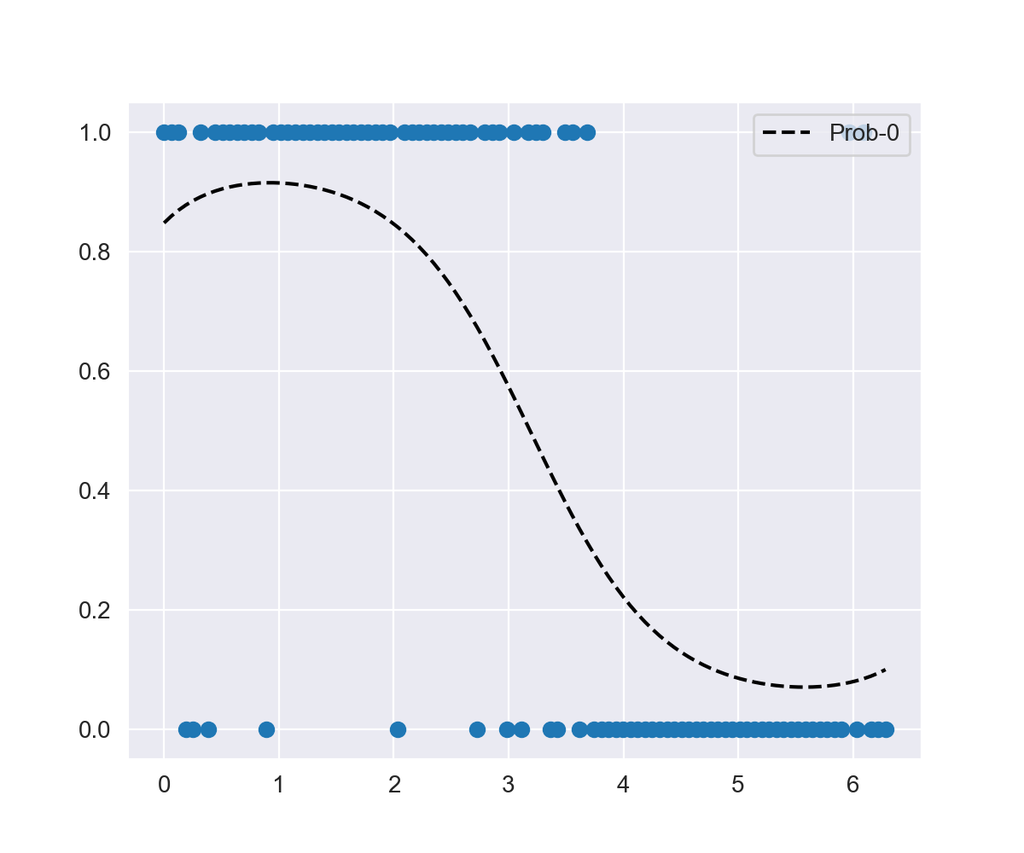

```python
fig = plt.figure(figsize=[6,5])

ax = plt.subplot(111)
# Plot original points
ax.scatter(df_poly.x, target_categorical)
# Plot predicted values of y
ax.plot(third_order_df.x, model.predict_proba(features)[:,1], 'k--', label='Prob-0')

ax.legend(loc=1)
plt.show()
```

How does Logistic Regression learn?

```python
model2 = LogisticRegression(C=5)
```

```python
model2.fit(features, target_categorical)
```

```
LogisticRegression(C=5)
```

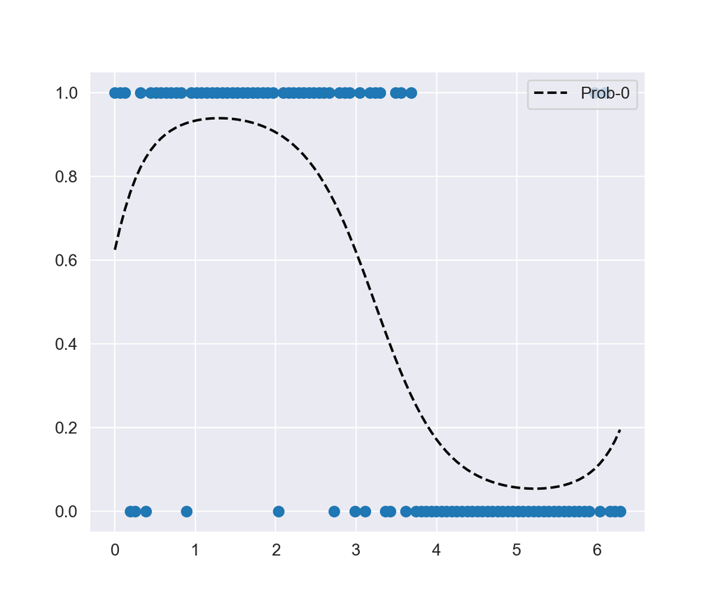

```python
fig = plt.figure(figsize=[6,5])

ax = plt.subplot(111)
# Plot original points
ax.scatter(df_poly.x, target_categorical)
# Plot predicted values of y
ax.plot(third_order_df.x, model2.predict_proba(features)[:,1], 'k--', label='Prob-0')

ax.legend(loc=1)
plt.show()
```

```python
model3 = LogisticRegression(C=0.25)
```

```python
model3.fit(features, target_categorical)
```

```
LogisticRegression(C=0.25)
```

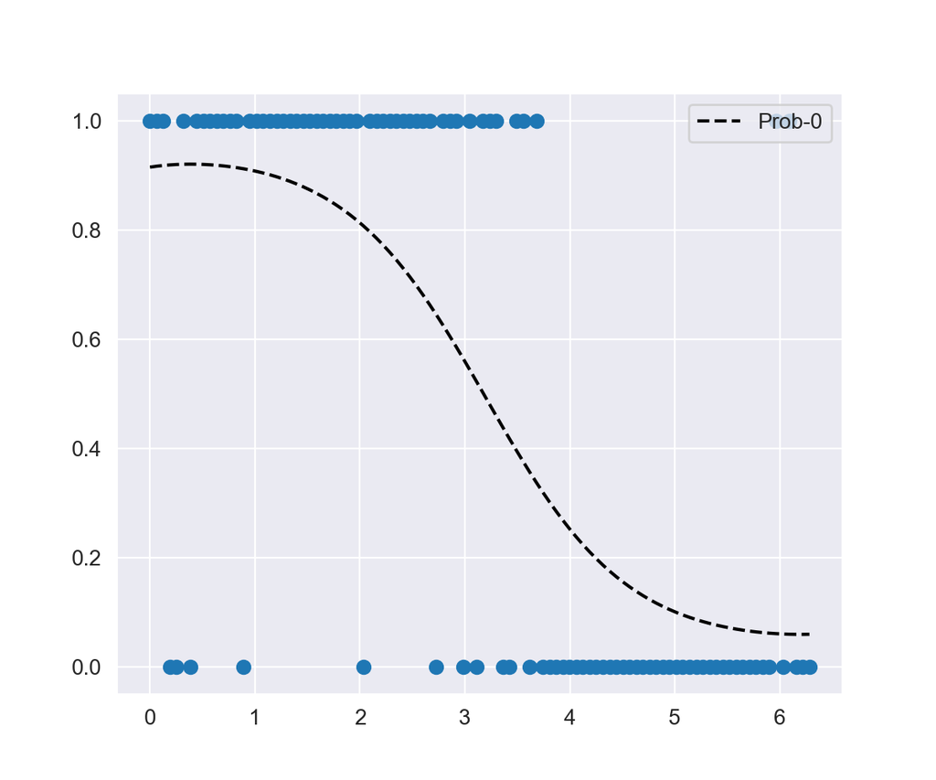

```python
fig = plt.figure(figsize=[6,5])

ax = plt.subplot(111)
# Plot original points
ax.scatter(df_poly.x, target_categorical)
# Plot predicted values of y
ax.plot(third_order_df.x, model3.predict_proba(features)[:,1], 'k--', label='Prob-0')

ax.legend(loc=1)
plt.show()
```

This is how the logistic regression behaves with different penalties, (values of C). Is there other penalty types?

```python
model4 = LogisticRegression(penalty='l2', C=0.25)
```

```python
model4.fit(features, target_categorical)
```

```
LogisticRegression(C=0.25)
```

```python
fig = plt.figure(figsize=[6,5])

ax = plt.subplot(111)
# Plot original points
ax.scatter(df_poly.x, target_categorical)
# Plot predicted values of y
ax.plot(third_order_df.x, model4.predict_proba(features)[:,1], 'k--', label='Prob-0')

ax.legend(loc=1)
plt.show()
```

[output not shown]

## 4. Regularized Regression

Let’s start with a similar dataframe, but with more parameters.

```python
# input feature
x = np.linspace(0, 2*np.pi, 100)

# noise
np.random.seed(321)
noise = np.random.normal(0, .5, 100)

# target variable
y = np.sin(x) + noise

# Create DataFrame with x and y
df = pd.DataFrame({'x' : x, 'y': y})
df.head()
```

|  | x | y |
| --- | --- | --- |
| 0 | 0.000000 | 0.086260 |
| 1 | 0.063467 | 0.881165 |
| 2 | 0.126933 | 0.145261 |
| 3 | 0.190400 | -0.252824 |
| 4 | 0.253866 | -0.320448 |

```python
df_sample = df.copy()

# Set seed for reproducible results
np.random.seed(555)

# Create 20 randomfeatures
for n in range(100):
    df_sample['s{}'.format(n)] = np.random.uniform(0, 2*np.pi, 100)
```

```python
df_sample.head()
```

|  | x | y | s0 | s1 | s2 | s3 | s4 | s5 | s6 | s7 | ... | s90 | s91 | s92 | s93 | s94 | s95 | s96 | s97 | s98 | s99 |
| --- | --- | --- | --- | --- | --- | --- | --- | --- | --- | --- | --- | --- | --- | --- | --- | --- | --- | --- | --- | --- | --- |
| 0 | 0.000000 | 0.086260 | 4.510285 | 4.243360 | 5.077364 | 5.775407 | 0.870371 | 1.042189 | 3.288845 | 1.005865 | ... | 0.401207 | 2.986740 | 3.419816 | 2.210869 | 4.116052 | 5.651802 | 2.931066 | 1.542499 | 2.299154 | 2.986066 |
| 1 | 0.063467 | 0.881165 | 0.300683 | 2.204225 | 0.492213 | 5.097731 | 0.541594 | 0.343164 | 4.840217 | 4.343630 | ... | 2.432486 | 1.130922 | 0.067541 | 2.857747 | 5.934834 | 5.213061 | 5.579050 | 4.092146 | 4.464422 | 5.644063 |
| 2 | 0.126933 | 0.145261 | 5.934292 | 4.499745 | 5.629712 | 0.721088 | 4.499597 | 1.054771 | 3.207139 | 2.356321 | ... | 3.335856 | 5.061090 | 0.854903 | 1.861820 | 0.216191 | 4.707951 | 1.171044 | 3.402163 | 5.652485 | 1.765618 |
| 3 | 0.190400 | -0.252824 | 4.312653 | 1.798761 | 6.126937 | 0.804294 | 4.019667 | 5.314475 | 3.989411 | 2.739722 | ... | 0.430104 | 3.887071 | 0.294676 | 0.168721 | 4.298122 | 5.752676 | 5.008056 | 3.983089 | 5.742110 | 1.424242 |
| 4 | 0.253866 | -0.320448 | 3.651833 | 4.475723 | 5.188299 | 3.456177 | 3.971505 | 1.095373 | 6.279545 | 1.951886 | ... | 6.061850 | 5.710574 | 1.732244 | 4.721764 | 4.733892 | 5.386840 | 1.901648 | 3.090707 | 1.974244 | 4.010548 |

5 rows × 102 columns

```python
X_sample = df_sample.drop('y', axis=1)
```

### 4.1 Lasso Regression

```python
from sklearn.linear_model import Lasso
```

```python
lasso = Lasso(random_state=1234)
lasso.fit(X_sample, y)
```

```
Lasso(random_state=1234)
```

```python
fig = plt.figure(figsize=[6,5])

ax = plt.subplot(111)
# Plot original points
ax.scatter(df_sample.x, df_sample.y)
# Plot predicted values of y
ax.plot(df_sample.x, lasso.predict(X_sample), 'k--', label='model fit')
ax.legend(loc=1)
plt.show()
```

[output not shown]

```python
lasso = Lasso(alpha=2.0, random_state=1234)
lasso.fit(X_sample, y)
```

```
Lasso(alpha=2.0, random_state=1234)
```

```python
fig = plt.figure(figsize=[6,5])

ax = plt.subplot(111)
# Plot original points
ax.scatter(df_sample.x, df_sample.y)
# Plot predicted values of y
ax.plot(df_sample.x, lasso.predict(X_sample), 'k--', label='model fit')

ax.legend(loc=1)
plt.show()
```

[output not shown]

```python
print(lasso.coef_)
```

```
[-0.  0. -0. -0.  0.  0. -0. -0. -0.  0.  0. -0. -0.  0.  0. -0. -0. -0.
 -0.  0. -0.  0.  0.  0.  0. -0. -0. -0. -0. -0. -0. -0.  0. -0.  0. -0.
  0.  0.  0. -0. -0. -0.  0.  0. -0.  0.  0.  0.  0. -0.  0.  0.  0. -0.
  0. -0. -0.  0. -0.  0. -0.  0. -0. -0. -0.  0. -0. -0.  0.  0.  0.  0.
  0.  0.  0.  0.  0. -0. -0.  0.  0.  0. -0. -0. -0.  0. -0.  0.  0. -0.
 -0.  0. -0.  0.  0.  0.  0. -0. -0.  0.  0.]
```

```python
lasso = Lasso(alpha=0.01, random_state=1234)
lasso.fit(X_sample, y)
```

```
Lasso(alpha=0.01, random_state=1234)
```

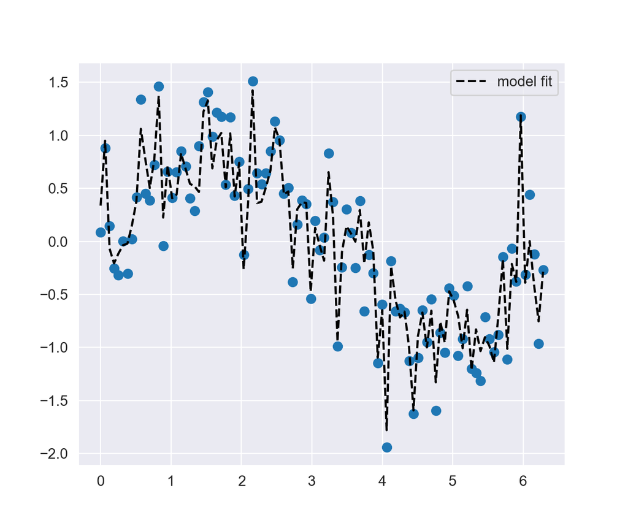

```python
fig = plt.figure(figsize=[6,5])

ax = plt.subplot(111)
# Plot original points
ax.scatter(df_sample.x, df_sample.y)
# Plot predicted values of y
ax.plot(df_sample.x, lasso.predict(X_sample), 'k--', label='model fit')

ax.legend(loc=1)
plt.show()
```

```python
print(lasso.coef_)
```

```
[-2.51917168e-01  4.10314859e-02  5.45436757e-03  1.93983589e-02
 -0.00000000e+00  3.71926650e-04 -2.91626816e-02 -7.30117603e-02
 -0.00000000e+00  2.35664422e-02  1.15328229e-02 -1.37269139e-01
 -8.55021573e-02  0.00000000e+00 -0.00000000e+00  0.00000000e+00
 -0.00000000e+00  2.31116907e-02 -7.69147144e-03  1.43637115e-02
 -4.59460085e-02  6.32005952e-02  0.00000000e+00  3.35372015e-02
 -2.04031104e-02 -2.47692101e-02  1.01483461e-02 -1.98289793e-02
  0.00000000e+00 -1.69208119e-02 -6.38448583e-02  4.88311922e-02
 -4.92076031e-02 -5.77076974e-02  1.46127834e-02  6.17103039e-02
  1.08025418e-02 -9.24093430e-03  1.39007203e-02 -3.45517512e-02
  7.75704597e-03  1.34676884e-02 -6.55351081e-02  0.00000000e+00
 -2.51704549e-02  2.19660309e-02 -6.18336806e-02 -0.00000000e+00
 -1.34811001e-03  8.01130519e-03  4.94648308e-02  2.74071927e-02
 -1.71572289e-02 -7.66719433e-02 -1.53841329e-02  4.25935667e-02
  0.00000000e+00  0.00000000e+00 -5.14947316e-02  5.38733880e-02
 -5.87659526e-02 -1.99279915e-02 -0.00000000e+00 -2.85859781e-02
  9.23077028e-03  3.66337147e-02 -8.92423823e-02 -3.19575719e-02
 -3.20845176e-02  6.37818412e-02  5.52303012e-02  9.54397855e-02
  0.00000000e+00  3.95943641e-03  2.42927819e-02 -4.34199201e-02
 -3.26335368e-02 -2.74058877e-02 -6.17839339e-02  0.00000000e+00
 -4.88893697e-02 -5.27947085e-02 -0.00000000e+00 -4.22261956e-02
 -3.17840242e-02  7.87870931e-02 -8.59615538e-02  6.18403170e-02
  8.91858350e-02  4.48748149e-06  1.86464362e-02  0.00000000e+00
 -8.18425037e-03  5.11828963e-02 -0.00000000e+00 -0.00000000e+00
 -2.09412108e-02  0.00000000e+00 -1.16449350e-01 -2.46500974e-02
 -1.53086323e-02]
```

### 4.2 Ridge Regression

```python
from sklearn.linear_model import Ridge
```

```python
# Default alpha=1.0
ridge = Ridge(alpha=1.0, random_state=1234)
ridge.fit(X_sample, y)
```

```
Ridge(random_state=1234)
```

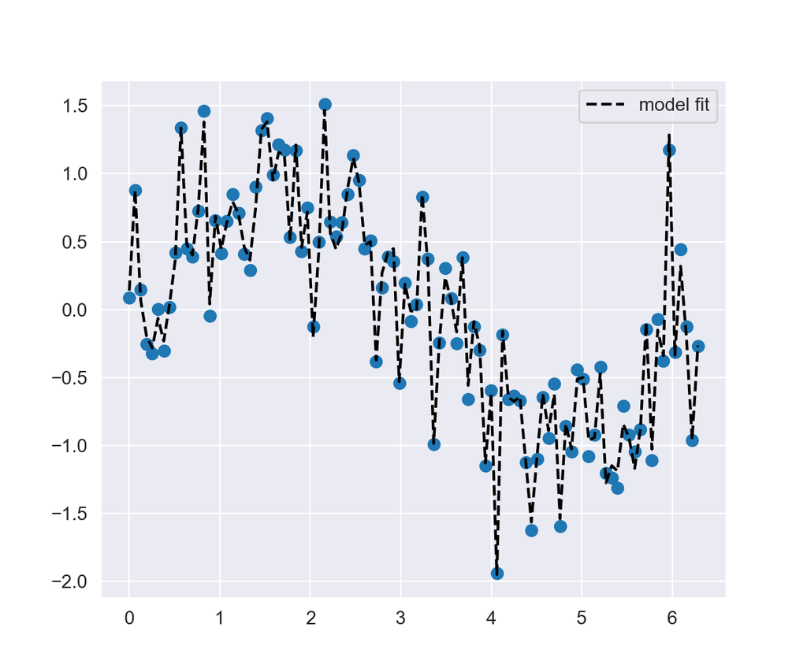

```python
fig = plt.figure(figsize=[6,5])

ax = plt.subplot(111)
# Plot original points
ax.scatter(df_sample.x, df_sample.y)
# Plot predicted values of y
ax.plot(df_sample.x, ridge.predict(X_sample), 'k--', label='model fit')
ax.legend(loc=1)
plt.show()
```

```python
ridge = Ridge(alpha=0.5, random_state=1234)
ridge.fit(X_sample, y)
```

```
Ridge(alpha=0.5, random_state=1234)
```

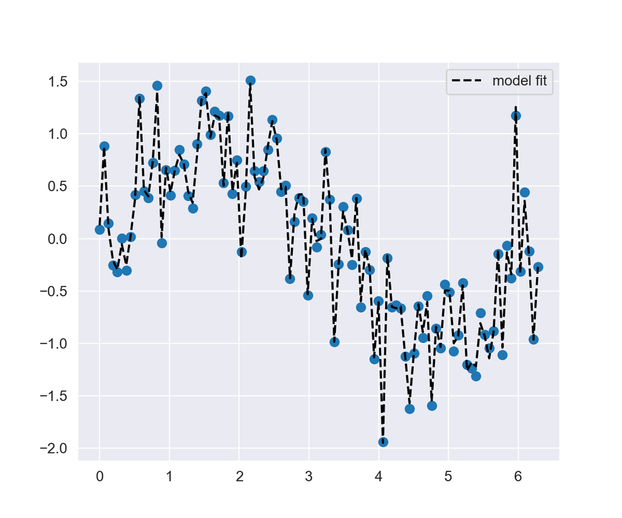

```python
fig = plt.figure(figsize=[6,5])

ax = plt.subplot(111)
# Plot original points
ax.scatter(df_sample.x, df_sample.y)
# Plot predicted values of y
ax.plot(df_sample.x, ridge.predict(X_sample), 'k--', label='model fit')
ax.legend(loc=1)
plt.show()
```

```python
print( ridge.coef_ )
```

```
[-0.30208389  0.0783116  -0.008561    0.08204715 -0.06670881  0.07344217
 -0.11053133 -0.01485217  0.04515549  0.04721998  0.05048001 -0.25218637
 -0.04353109 -0.13977087 -0.01749479  0.01417613  0.01891266 -0.00095329
 -0.05954435 -0.07859067 -0.06973464  0.07329633 -0.06157125  0.10146629
  0.01389787 -0.10182674  0.0189875  -0.02820367  0.08443438 -0.06468595
 -0.10173674  0.17575185 -0.12726992 -0.17792542 -0.02502084  0.06368206
  0.09362423 -0.11517384  0.01386887 -0.13302902  0.00483455 -0.01414969
 -0.11959204 -0.15977016 -0.07539503  0.01780257 -0.02981305 -0.04971948
 -0.08259787  0.02318377  0.04660821  0.04864542 -0.08192852 -0.21225363
  0.0346915   0.07696095  0.01383101  0.01961826 -0.00164144  0.1371216
 -0.16776161 -0.11472388 -0.05048734 -0.02597299  0.06294517  0.1578618
 -0.1916048  -0.14130211 -0.1370536   0.05279126  0.10142856  0.09115189
  0.02825284 -0.11447375  0.06534487 -0.1014944  -0.11054924  0.09896938
 -0.10404176 -0.08390335 -0.04848419 -0.11209537 -0.03301159 -0.07710636
 -0.08741069  0.07106847 -0.07141465  0.08216359  0.22342028 -0.05613415
  0.00582488 -0.14286738  0.05970706  0.16863328  0.00186668  0.00269799
 -0.04637963  0.06639775 -0.18638498 -0.03430204 -0.05040116]
```

### 4.3 Elastic Net Regression

```python
from sklearn.linear_model import ElasticNet
```

```python
enet = ElasticNet(alpha=1.0,
                  l1_ratio=0.5,
                  random_state=1234)

enet.fit(X_sample, y)
```

```
ElasticNet(random_state=1234)
```

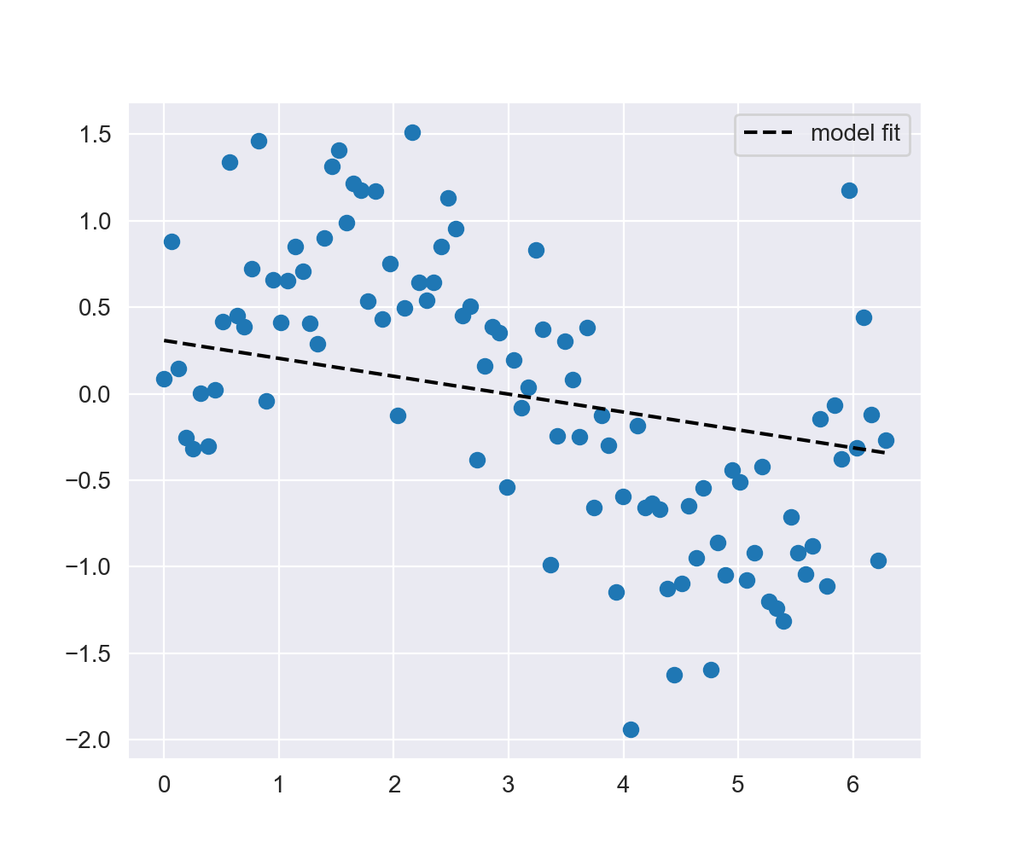

```python
fig = plt.figure(figsize=[6,5])

ax = plt.subplot(111)
# Plot original points
ax.scatter(df_sample.x, df_sample.y)
# Plot predicted values of y
ax.plot(df_sample.x, enet.predict(X_sample), 'k--', label='model fit')
ax.legend(loc=1)
plt.show()
```

```python
print( enet.coef_ )
```

```
[-0.1033666  0.        -0.        -0.         0.         0.
 -0.        -0.        -0.         0.         0.        -0.
 -0.         0.         0.        -0.        -0.         0.
 -0.         0.        -0.         0.         0.         0.
 -0.        -0.        -0.        -0.        -0.        -0.
 -0.        -0.         0.        -0.         0.        -0.
  0.         0.        -0.        -0.        -0.        -0.
  0.         0.        -0.         0.         0.         0.
  0.        -0.         0.         0.         0.        -0.
  0.        -0.        -0.         0.        -0.         0.
 -0.         0.        -0.        -0.        -0.         0.
 -0.        -0.         0.         0.         0.         0.
  0.         0.         0.        -0.         0.        -0.
 -0.         0.         0.         0.        -0.        -0.
 -0.         0.        -0.         0.         0.        -0.
  0.         0.        -0.         0.         0.         0.
  0.        -0.        -0.         0.        -0.       ]
```

```python
enet = ElasticNet(alpha=1.0,
                  l1_ratio=1.0,
                  random_state=1234)

enet.fit(X_sample, y)
```

```
ElasticNet(l1_ratio=1.0, random_state=1234)
```

```python
fig = plt.figure(figsize=[6,5])

ax = plt.subplot(111)
# Plot original points
ax.scatter(df_sample.x, df_sample.y)
# Plot predicted values of y
ax.plot(df_sample.x, enet.predict(X_sample), 'k--', label='model fit')
ax.legend(loc=1)
plt.show()
```

[output not shown]

```python
print( enet.coef_ )
```

```
[-0.  0. -0. -0.  0.  0. -0. -0. -0.  0.  0. -0. -0.  0.  0. -0. -0. -0.
 -0.  0. -0.  0.  0.  0.  0. -0. -0. -0. -0. -0. -0. -0.  0. -0.  0. -0.
  0.  0.  0. -0. -0. -0.  0.  0. -0.  0.  0.  0.  0. -0.  0.  0.  0. -0.
  0. -0. -0.  0. -0.  0. -0.  0. -0. -0. -0.  0. -0. -0.  0.  0.  0.  0.
  0.  0.  0.  0.  0. -0. -0.  0.  0.  0. -0. -0. -0.  0. -0.  0.  0. -0.
 -0.  0. -0.  0.  0.  0.  0. -0. -0.  0.  0.]
```

```python
enet = ElasticNet(alpha=0.01,
                  l1_ratio=0.5,
                  random_state=1234)

enet.fit(X_sample, y)
```

```
ElasticNet(alpha=0.01, random_state=1234)
```

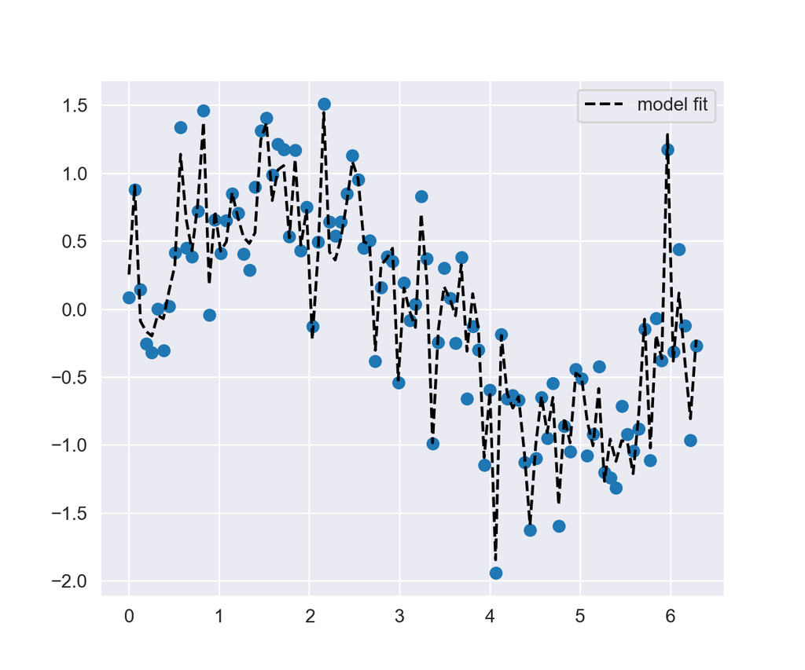

```python
fig = plt.figure(figsize=[6,5])

ax = plt.subplot(111)
# Plot original points
ax.scatter(df_sample.x, df_sample.y)
# Plot predicted values of y
ax.plot(df_sample.x, enet.predict(X_sample), 'k--', label='model fit')
ax.legend(loc=1)
plt.show()
```

```python
print( enet.coef_ )
```

```
[-0.26486045  0.04298242  0.00742904  0.03848651 -0.00369298  0.01630889
 -0.03969584 -0.06838583  0.          0.01223765  0.         -0.16079311
 -0.08590186 -0.          0.          0.00337793  0.          0.05439315
 -0.00560836  0.         -0.05292692  0.06151592 -0.          0.03678179
 -0.01437262 -0.01604844  0.04530877 -0.0125807   0.00112914 -0.02412691
 -0.09274653  0.07007337 -0.06400848 -0.06148557  0.01562378  0.05619311
  0.00425738 -0.03156357  0.01463145 -0.04938065  0.01605828  0.02144099
 -0.09605786  0.         -0.00775791  0.04290143 -0.07727029 -0.02384968
 -0.00279812  0.01140535  0.0814785   0.03202166 -0.04087497 -0.1070377
 -0.02090587  0.0609347   0.00652478  0.         -0.05690183  0.06219168
 -0.08034505 -0.03593893  0.         -0.02842273  0.01739034  0.05569333
 -0.11668482 -0.02039673 -0.02872962  0.06056502  0.05273333  0.09800944
  0.02009541 -0.          0.01641543 -0.08282496 -0.05206842 -0.02491
 -0.06816818 -0.         -0.05921067 -0.07776435 -0.00641733 -0.0514239
 -0.05477854  0.07539555 -0.11812429  0.05463899  0.1042674   0.00037661
  0.0363306  -0.         -0.00105311  0.05472615  0.         -0.00185223
 -0.04425153 -0.01161046 -0.11871534 -0.03399284 -0.04752461]
```

```python
enet = ElasticNet(alpha=1.0,
                  l1_ratio=0.1,
                  random_state=1234)

enet.fit(X_sample, y)
```

```
ElasticNet(l1_ratio=0.1, random_state=1234)
```

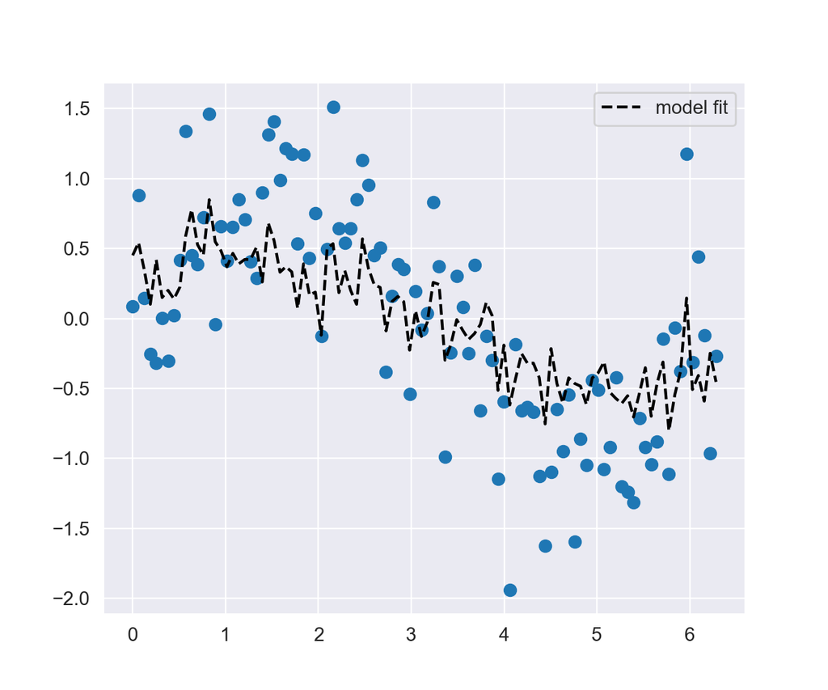

```python
fig = plt.figure(figsize=[6,5])

ax = plt.subplot(111)
# Plot original points
ax.scatter(df_sample.x, df_sample.y)
# Plot predicted values of y
ax.plot(df_sample.x, enet.predict(X_sample), 'k--', label='model fit')
ax.legend(loc=1)
plt.show()
```

```python
print( enet.coef_ )
```

```
[-1.68786818e-01  0.00000000e+00 -0.00000000e+00 -8.69081194e-03
  0.00000000e+00  0.00000000e+00 -0.00000000e+00 -2.74644068e-02
 -0.00000000e+00  6.10833269e-03  0.00000000e+00 -2.18782907e-02
 -2.08478104e-02  0.00000000e+00 -0.00000000e+00  0.00000000e+00
 -1.34108154e-03  0.00000000e+00 -0.00000000e+00  2.67402422e-02
 -6.04518012e-05  9.18142722e-03  0.00000000e+00  6.63515493e-03
 -0.00000000e+00 -5.80086654e-03 -0.00000000e+00 -2.18650865e-02
 -0.00000000e+00 -0.00000000e+00 -1.54386802e-02 -0.00000000e+00
  0.00000000e+00 -0.00000000e+00  0.00000000e+00  0.00000000e+00
  0.00000000e+00  0.00000000e+00 -0.00000000e+00 -0.00000000e+00
 -0.00000000e+00  0.00000000e+00 -0.00000000e+00  8.23499114e-03
 -0.00000000e+00  2.35320954e-03  0.00000000e+00  0.00000000e+00
  0.00000000e+00 -0.00000000e+00  1.05831559e-02  0.00000000e+00
  0.00000000e+00 -1.25327207e-02 -0.00000000e+00  0.00000000e+00
 -5.51802084e-03  0.00000000e+00 -5.66401067e-04  1.07939263e-02
 -1.45990846e-02  0.00000000e+00 -1.52939309e-03 -6.72135219e-03
 -0.00000000e+00  0.00000000e+00 -1.20157609e-02 -0.00000000e+00
  0.00000000e+00  1.71529833e-02  0.00000000e+00  3.05872440e-02
  0.00000000e+00  1.26396096e-02  6.33190454e-04 -0.00000000e+00
  0.00000000e+00 -9.60911056e-04 -0.00000000e+00  0.00000000e+00
  0.00000000e+00  0.00000000e+00 -0.00000000e+00 -0.00000000e+00
 -0.00000000e+00  1.28186954e-02 -2.18373241e-02  1.53391018e-02
  8.75747993e-03 -0.00000000e+00  0.00000000e+00  2.42576913e-02
 -9.56634532e-03  2.49756289e-02  0.00000000e+00  1.34913684e-03
  0.00000000e+00  0.00000000e+00 -6.27207333e-02  0.00000000e+00
  0.00000000e+00]
```

👏 Congratulations, you have completed the Regression Workbook!